# 01_quenched_fraction

## 1. Load the catalog

The code first looks for the catalog in a local checkout of the website. If it is not present, Astropy reads the same file from the public data URL. This makes the notebook work both inside the repository and as a standalone download.

```python
from pathlib import Path

import matplotlib.pyplot as plt
import numpy as np
from astropy.stats import binom_conf_interval
from astropy.table import Table

CATALOG_NAME = "ELVES-Dwarf_master_cat_v1.fits"
CATALOG_URL = "https://elves-surveys.github.io/data/elves-dwarf/" + CATALOG_NAME
LOCAL_CANDIDATES = (Path("../../data/elves-dwarf") / CATALOG_NAME, Path("public/data/elves-dwarf") / CATALOG_NAME)
catalog_source = next((path for path in LOCAL_CANDIDATES if path.exists()), CATALOG_URL)

catalog = Table.read(catalog_source)
for column in catalog.colnames:
    if catalog[column].dtype.kind == "S":
        catalog[column] = catalog[column].astype(str)

print(f"Loaded {len(catalog)} rows from {catalog_source}")
print("Membership classes:")
for status in np.unique(catalog["status"]):
    print(f"  {status}: {np.count_nonzero(catalog['status'] == status)}")
```

```
Loaded 207 rows from ../../data/elves-dwarf/ELVES-Dwarf_master_cat_v1.fits
Membership classes:
  Confirmed: 39
  Not Observed: 17
  Rejected: 131
  Unconfirmed: 20
```

## 2. Set the plotting style

The figures below follow the same look as the original analysis notebook (serif fonts, inward-facing major/minor ticks on all four sides, a frameless legend). We set this with `plt.rcParams.update` instead of loading the project's `.mplstyle` file directly, so the tutorial has no dependency on it and does not require a local LaTeX installation.

```python
plt.rcParams.update({
    "font.family": "serif", "font.size": 12, "mathtext.fontset": "dejavuserif",
    "axes.linewidth": 1.3, "axes.titlesize": "large", "axes.titlepad": 10.0,
    "axes.labelpad": 4.0, "axes.formatter.use_mathtext": True,
    "xtick.top": True, "xtick.bottom": True, "xtick.direction": "in", "xtick.minor.visible": True,
    "xtick.major.size": 6.0, "xtick.minor.size": 3.5, "xtick.major.width": 1.5, "xtick.minor.width": 0.8, "xtick.major.pad": 7.0,
    "ytick.left": True, "ytick.right": True, "ytick.direction": "in", "ytick.minor.visible": True,
    "ytick.major.size": 6.0, "ytick.minor.size": 3.5, "ytick.major.width": 1.5, "ytick.minor.width": 0.8, "ytick.major.pad": 7.0,
    "grid.linestyle": "--", "grid.alpha": 0.6,
    "legend.frameon": False, "legend.borderpad": 0.5, "legend.labelspacing": 0.3,
    "legend.handletextpad": 0.8, "legend.borderaxespad": 0.8, "errorbar.capsize": 3,
    "figure.figsize": (7.2, 4.5), "figure.dpi": 100, "savefig.dpi": 200, "savefig.bbox": "tight",
})
```

## 3. Define the analysis sample

For this tutorial we use:

- objects whose catalog `status` is `Confirmed`;
- an absolute-magnitude limit of $M_V < -9$; and
- objects with a usable $g-i$ color, either measured directly or converted from a valid $g-r$ color.

We calculate absolute magnitude from the apparent Sersic magnitude and the host distance:

$$M_V = m_V - 5\log_{10}(D_{\rm host}/{\rm Mpc}) - 25.$$

When `gi_sersic` is missing but `gr_sersic` is valid, we use the relation from the original notebook, $(g-i)=1.53(g-r)-0.032$. Catalog placeholders such as `999` are treated as missing, not as physical colors.

```python
M_V_LIMIT = -9.0

confirmed = catalog[np.asarray(catalog["status"]).astype(str) == "Confirmed"].copy()
confirmed["M_V"] = confirmed["m_V_sersic"] - (5 * np.log10(confirmed["host_dist"]) + 25)
bright = confirmed[confirmed["M_V"] < M_V_LIMIT].copy()

gi = np.asarray(np.ma.filled(bright["gi_sersic"], np.nan), dtype=float)
gr = np.asarray(np.ma.filled(bright["gr_sersic"], np.nan), dtype=float)
valid_gi, valid_gr = np.isfinite(gi) & (np.abs(gi) < 5), np.isfinite(gr) & (np.abs(gr) < 5)
converted = ~valid_gi & valid_gr
gi[converted] = 1.53 * gr[converted] - 0.032
valid_color = np.isfinite(gi) & (np.abs(gi) < 5)

sample = bright[valid_color].copy()
sample["g_i_used"] = gi[valid_color]
sample["color_source"] = np.where(valid_gi[valid_color], "catalog g-i", "converted from g-r")

print(f"Confirmed satellites: {len(confirmed)}")
print(f"After M_V < {M_V_LIMIT:g}: {len(bright)}")
print(f"With a usable color: {len(sample)}")
print(f"Excluded for missing color: {len(bright) - len(sample)}")
sample[["name", "host", "M_V", "g_i_used", "color_source"]][:10]
```

```
Confirmed satellites: 39
After M_V < -9: 34
With a usable color: 31
Excluded for missing color: 3
```

*Table length=10*

| name str13 | host str10 | M_V float64 | g_i_used float64 | color_source str18 |
| --- | --- | --- | --- | --- |
| Antlia B | NGC3109 | -9.7 | 0.7322349999999991 | converted from g-r |
| ESO294-010 | NGC0055 | -11.3 | 0.6510000000000016 | catalog g-i |
| DDO044 | NGC2403 | -12.9 | 0.8000000000000007 | catalog g-i |
| MADCASH-2 | NGC4214 | -9.150000000000002 | 0.6258999999999996 | converted from g-r |
| DDO113 | NGC4214 | -12.2 | 0.7314700000000008 | converted from g-r |
| NGC4190 | NGC4214 | -14.5 | 0.5800000000000005 | converted from g-r |
| NGC4163 | NGC4214 | -14.3 | 0.6259000000000022 | converted from g-r |
| SMDG0740+4032 | DDO046 | -11.966986767562194 | 0.74371 | converted from g-r |
| dw0741p4005 | DDO046 | -11.721986767562193 | 0.22045 | converted from g-r |
| KK65 | DDO047 | -14.724110282662078 | 0.5019699999999999 | converted from g-r |

## 4. Classify quenched satellites

Following the color--magnitude definition used in the original notebook, a satellite is classified as quenched when

$$(g-i) > -0.067M_V - 0.23.$$

This is a photometric classification. It is not a direct measurement of star-formation rate, and objects without a usable color are excluded from the denominator.

```python
sample["quenching_boundary"] = -0.067 * sample["M_V"] - 0.23
sample["quenched"] = sample["g_i_used"] > sample["quenching_boundary"]

n_total = len(sample)
n_quenched = int(np.count_nonzero(sample["quenched"]))
fraction = n_quenched / n_total
interval = binom_conf_interval(n_quenched, n_total, confidence_level=0.68, interval="jeffreys")

print(f"Quenched: {n_quenched}/{n_total}")
print(f"Overall quenched fraction: {fraction:.3f} (68% Jeffreys interval: {interval[0]:.3f}--{interval[1]:.3f})")
sample[["name", "host", "M_V", "g_i_used", "quenched"]]
```

```
Quenched: 11/31
Overall quenched fraction: 0.355 (68% Jeffreys interval: 0.275--0.444)
```

*Table length=31*

| name str13 | host str10 | M_V float64 | g_i_used float64 | quenched bool |
| --- | --- | --- | --- | --- |
| Antlia B | NGC3109 | -9.7 | 0.7322349999999991 | True |
| ESO294-010 | NGC0055 | -11.3 | 0.6510000000000016 | True |
| DDO044 | NGC2403 | -12.9 | 0.8000000000000007 | True |
| MADCASH-2 | NGC4214 | -9.150000000000002 | 0.6258999999999996 | True |
| DDO113 | NGC4214 | -12.2 | 0.7314700000000008 | True |
| NGC4190 | NGC4214 | -14.5 | 0.5800000000000005 | False |
| NGC4163 | NGC4214 | -14.3 | 0.6259000000000022 | False |
| SMDG0740+4032 | DDO046 | -11.966986767562194 | 0.74371 | True |
| dw0741p4005 | DDO046 | -11.721986767562193 | 0.22045 | False |
| ... | ... | ... | ... | ... |
| dw0605m3325 | NGC2188 | -13.356809804143502 | 0.244 | False |
| AGC731457 | NGC3274 | -13.943000000000001 | 0.285 | False |
| dw1030p2746 | NGC3274 | -11.925 | 0.769 | True |
| dw1245p6158 | NGC4605 | -10.955464915613383 | 0.89518 | True |
| LEDA104868 | NGC4700 | -15.156413360750841 | 0.362 | False |
| dw1250m1045 | NGC4700 | -14.204413360750841 | 0.479 | False |
| UGC07950 | NGC4707 | -15.731237978659603 | 0.37192000000000003 | False |
| dw1250p5056 | NGC4707 | -10.297237978659602 | 0.24645999999999998 | False |
| dw1008p7038b | UGC05423 | -12.080618099158634 | 0.4729 | False |
| dw1009p7032 | UGC05423 | -11.983618099158633 | 0.44994999999999996 | False |

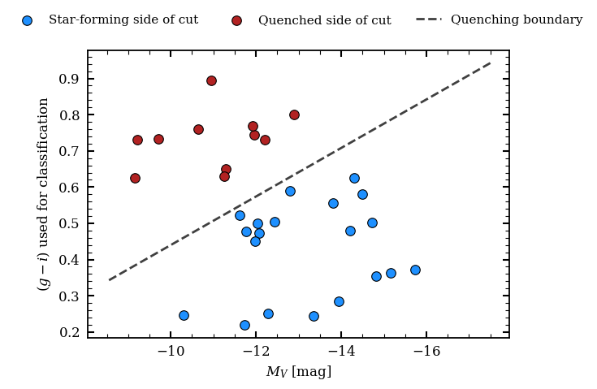

```python
is_quenched = np.asarray(sample["quenched"], dtype=bool)
magnitude_grid = np.linspace(-17.5, -8.5, 200)

fig, ax = plt.subplots(figsize=(6.7, 4.6))
ax.scatter(sample["M_V"][~is_quenched], sample["g_i_used"][~is_quenched], label="Star-forming side of cut",
           color="dodgerblue", edgecolor="k", linewidth=0.8, s=70, zorder=5)
ax.scatter(sample["M_V"][is_quenched], sample["g_i_used"][is_quenched], label="Quenched side of cut",
           color="firebrick", edgecolor="k", linewidth=0.8, s=70, zorder=5)
ax.plot(magnitude_grid, -0.067 * magnitude_grid - 0.23, color="0.25", linestyle="--", lw=2,
        label="Quenching boundary", zorder=2)

ax.set(xlabel=r"$M_V$ [mag]", ylabel=r"$(g-i)$ used for classification")
ax.invert_xaxis()
ax.legend(loc="upper center", bbox_to_anchor=(0.5, 1.18), ncol=3, fontsize=11)
plt.show()
```

## 5. Measure the quenched fraction versus stellar mass

For each stellar-mass bin, the estimator is simply $f_q=k/n$, where $k$ is the number classified as quenched and $n$ is the number with a usable color. We use a 68% Jeffreys binomial interval because the bins contain small samples and may have $k=0$ or $k=n$.

The bin edges below follow the compact calculation in the original notebook. Try changing them to see how small-number statistics affect the result.

```python
def binned_quenched_fraction(log_mass, quenched, bin_edges):
    """Return f_q and 68% Jeffreys intervals in stellar-mass bins."""
    rows = []
    for left, right in zip(bin_edges[:-1], bin_edges[1:]):
        in_bin = (log_mass >= left) & (log_mass < right)
        n = int(np.count_nonzero(in_bin))
        if n == 0:
            continue
        k = int(np.count_nonzero(quenched & in_bin))
        lower, upper = binom_conf_interval(k, n, confidence_level=0.68, interval="jeffreys")
        rows.append((left, right, np.mean(log_mass[in_bin]), n, k, k / n, lower, upper))

    names = ("logM_left", "logM_right", "mean_logM", "N", "N_quenched", "f_quenched", "f_lower", "f_upper")
    return Table(rows=rows, names=names)
```

```python
mass_bins = np.array([5.0, 6.0, 6.6, 7.5, 9.1])
binned = binned_quenched_fraction(
    np.asarray(sample["log_m_star"], dtype=float),
    np.asarray(sample["quenched"], dtype=bool),
    mass_bins,
)
for column in ("mean_logM", "f_quenched", "f_lower", "f_upper"):
    binned[column].info.format = ".3f"
binned
```

*Table length=4*

| logM_left float64 | logM_right float64 | mean_logM float64 | N int64 | N_quenched int64 | f_quenched float64 | f_lower float64 | f_upper float64 |
| --- | --- | --- | --- | --- | --- | --- | --- |
| 5.0 | 6.0 | 5.733 | 4 | 3 | 0.750 | 0.500 | 0.894 |
| 6.0 | 6.6 | 6.413 | 10 | 4 | 0.400 | 0.262 | 0.556 |
| 6.6 | 7.5 | 7.033 | 12 | 4 | 0.333 | 0.216 | 0.477 |
| 7.5 | 9.1 | 7.706 | 5 | 0 | 0.000 | 0.000 | 0.171 |

## 6. Compare with reference quenched-fraction relations

To put the ELVES-Dwarf measurement in context, we overplot three published/derived reference relations that were digitized from the original analysis notebook's figure, each with a 68% confidence band:

- **MW + M31**: the quenched fraction among Milky Way and M31 satellites.
- **ELVES**: the average quenched fraction of confirmed satellites in the ELVES survey (Carlsten et al. 2022).
- **ELVES-Field**: the quenched fraction of isolated, ELVES-selected field dwarfs, i.e. the non-satellite comparison sample from the same survey.

These three curves are fixed arrays, not recomputed from raw data here — they only serve as a visual comparison for the ELVES-Dwarf result measured above.

```python
# Each array holds (log M_star/Msun, f_quenched) rows; "_lower"/"_upper" share the
# same x-values with the 68% confidence band edges. Digitized from the original
# analysis notebook's figure and rounded to 4 decimals (well below digitization error).

MW_M31_q = np.array([(5.4949, 0.9487), (6.4964, 1.0000), (7.4920, 0.8326), (8.4993, 0.6667), (9.5007, 0.0000)])
MW_M31_q_lower = np.array([(5.4949, 0.8507), (6.4964, 0.8326), (7.4978, 0.6003), (8.4993, 0.3816), (9.5007, 0.0000)])
MW_M31_q_upper = np.array([(5.5007, 0.9834), (6.4964, 1.0000), (7.4978, 0.8959), (8.4934, 0.8130), (9.5007, 0.4570)])

# ELVES average quenched fraction (Carlsten et al. 2022, confirmed satellites)
elves_confirmed_q = np.array([(5.7423, 0.8506), (6.2526, 0.8651), (6.7423, 0.7523), (7.2474, 0.6612),
                               (7.7474, 0.7335), (8.2474, 0.3923), (8.7474, 0.3634), (9.2474, 0.1263)])
elves_confirmed_q_lower = np.array([(5.7526, 0.7928), (6.2526, 0.8145), (6.7423, 0.6959), (7.2474, 0.5961),
                                     (7.7474, 0.6684), (8.2474, 0.2983), (8.7474, 0.2376), (9.2320, 0.0583)])
elves_confirmed_q_upper = np.array([(5.7526, 0.8954), (6.2423, 0.9027), (6.7577, 0.7957), (7.2474, 0.7205),
                                     (7.7474, 0.7913), (8.2474, 0.4949), (8.7474, 0.5137), (9.2474, 0.2839)])

# ELVES-Field, isolated field dwarfs (Carlsten et al. 2022)
elves_field_q = np.array([(6.5, 0.3309), (7.5, 0.1577), (8.5, 0.0000)])
elves_field_q_lower = np.array([(6.5, 0.2263), (7.5, 0.0848), (8.5, 0.0000)])
elves_field_q_upper = np.array([(6.5, 0.4543), (7.5, 0.2736), (8.5, 0.1172)])
```

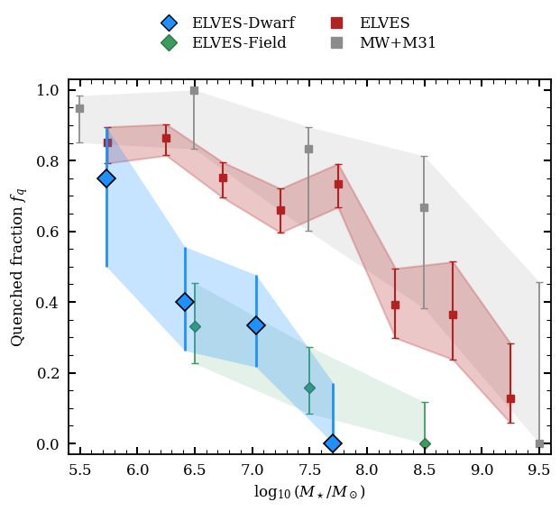

```python
from matplotlib.lines import Line2D

x = np.asarray(binned["mean_logM"], dtype=float)
y = np.asarray(binned["f_quenched"], dtype=float)
lower = np.asarray(binned["f_lower"], dtype=float)
upper = np.asarray(binned["f_upper"], dtype=float)
field_color = "#3A9D5D"

fig, ax = plt.subplots(figsize=(6.9, 5.4))

# ELVES (Carlsten+22 average, confirmed satellites)
ax.fill_between(elves_confirmed_q[:, 0], elves_confirmed_q_upper[:, 1], elves_confirmed_q_lower[:, 1],
                facecolor="firebrick", edgecolor="firebrick", alpha=0.25, lw=1.5, zorder=1)
ax.errorbar(elves_confirmed_q[:, 0], elves_confirmed_q[:, 1], fmt="s", mfc="firebrick", color="firebrick",
            markersize=6, lw=1.5, zorder=2,
            yerr=[elves_confirmed_q[:, 1] - elves_confirmed_q_lower[:, 1],
                  elves_confirmed_q_upper[:, 1] - elves_confirmed_q[:, 1]])

# MW + M31
ax.fill_between(MW_M31_q[:, 0], MW_M31_q_upper[:, 1], MW_M31_q_lower[:, 1], color="0.55", alpha=0.14, lw=0, zorder=0)
ax.errorbar(MW_M31_q[:, 0], MW_M31_q[:, 1], fmt="s", mfc="0.55", color="0.55", markersize=6, elinewidth=1.3, zorder=1,
            yerr=[MW_M31_q[:, 1] - MW_M31_q_lower[:, 1], MW_M31_q_upper[:, 1] - MW_M31_q[:, 1]])

# ELVES-Field (isolated field dwarfs)
ax.fill_between(elves_field_q[:, 0], elves_field_q_upper[:, 1], elves_field_q_lower[:, 1],
                color=field_color, alpha=0.14, lw=0, zorder=0)
ax.errorbar(elves_field_q[:, 0], elves_field_q[:, 1], fmt="D", mfc=field_color, mec="#357048", color=field_color,
            markersize=6, elinewidth=1.3, zorder=1,
            yerr=[elves_field_q[:, 1] - elves_field_q_lower[:, 1], elves_field_q_upper[:, 1] - elves_field_q[:, 1]])

# ELVES-Dwarf, computed above
ax.errorbar(x, y, yerr=np.vstack((y - lower, upper - y)), fmt="D", color="dodgerblue", mec="k", mew=1.2,
            markersize=10, lw=2, capsize=0, zorder=10)
ax.fill_between(x, lower, upper, color="dodgerblue", alpha=0.25, lw=0, zorder=9)

handles = [
    Line2D([], [], marker="D", ls="", mfc="dodgerblue", mec="k", ms=9, label="ELVES-Dwarf"),
    Line2D([], [], marker="D", ls="", mfc=field_color, mec="#357048", ms=9, label="ELVES-Field"),
    Line2D([], [], marker="s", ls="", color="firebrick", ms=8, label="ELVES"),
    Line2D([], [], marker="s", ls="", color="0.55", ms=9, label="MW+M31"),
]
ax.legend(handles=handles, loc="upper center", bbox_to_anchor=(0.47, 1.22), ncols=2,
          fontsize=12, handletextpad=0.5, labelspacing=0.3, columnspacing=1.8)

ax.set(xlabel=r"$\log_{10}(M_\star/M_\odot)$", ylabel=r"Quenched fraction $f_q$", xlim=(5.4, 9.6), ylim=(-0.03, 1.03))
plt.show()
```

## Interpretation and next steps

This tutorial reports the fraction for the explicitly selected color-valid sample. It does **not** perform completeness weighting, statistical background subtraction, or a sensitivity analysis for alternative quenching definitions. Those choices should be revisited for a publication-level measurement. The MW+M31, ELVES, and ELVES-Field curves are fixed reference arrays for visual comparison, not independently reproduced here.

Useful experiments:

- change `M_V_LIMIT` and the stellar-mass bins;
- compare direct $g-i$ measurements with colors converted from $g-r$;
- inspect how the result changes if objects without a usable color are assigned a classification from independent star-formation indicators;
- split the sample by host stellar mass or isolation; and
- join the satellite and host catalogs for additional host properties.

When publishing results from these data, cite the release paper listed in the [ELVES-Dwarf data documentation](https://elves-surveys.github.io/catalogs/elves-dwarf/).